# R extRemes Test with CESM data and some horesplay with ensembles

Processing for Precipitation Daily Extremes Using CESM Model Output.

Warning Typos are Legion.

Load Required Libraries

```r
library(ncdf4)     # processing netCDF data
library(lubridate) # processing dates and time
library(reshape2)  # manipulating data frames
library(extRemes)  # extreme data analysis
library(beanplot)  # trying to use the beanplot routine since box whiskers gave me some heartburn
```

Let’s start by identifying specific points, days and ensembles from which to pull data.

It’s nice to put this data up top to make changing locatons easier.

```r
location_name = "Rapid City"
period_span   = 30.
target_lon  = -104. # degrees east
target_lat  =   44. # degrees north
n_ensembles = 15
```

And we should include our time periods. Here, we have a baseline period and a future period

```r
base_start      = 1976              # start year
base_end        = base_start + 30-1 # end year  (just before our simulations diverge)
per1_start      = 2020              # start
per1_end        = per1_start + 30-1 # end year
```

And while I am up here I am defining a “wetting rain” even threshold as any rain event exceeding 0.1" per day

```r
wetting_rain_treshold = 0.1 * 25.4 # in -> mm (0.1 in = 2.54 )
```

CESM files can be found at

“http://kyrill.ias.sdsmt.edu:8080/thredds/catalog.html”

```r
URL_Root_Directory <- "http://kyrill.ias.sdsmt.edu:8080/thredds/dodsC/CESM_SODAK/"
# Here is the variable we want to extract
#  these should match the files names since the variable in the file and file name match
target_variable = "PRECT"
variable_name   = "Total Daily Precip"
variable_units  = "mm" # after post processing (starts as m/s)
# get URL files
RCP_85_File  = paste(target_variable,
                     "_RCP85_SODAK_DAILY_1920-2100.nc4",
                     sep="")
RCP_45_File  = paste(target_variable,
                     "_RCP45_SODAK_DAILY_1920-2080.nc4",
                     sep="")
# make the final URLs for extracting with the "paste" function
URL_85  = paste(URL_Root_Directory,  # string 1 to concatenate
                RCP_85_File,         # string 2 to concatenate
                sep=""               # separation character ("" = none)
               )
URL_45  = paste(URL_Root_Directory,  # string 1 to concatenate
                RCP_45_File,         # string 2 to concatenate
                sep=""               # separation character ("" = none)
               )
```

We now open the files…

the output of these functions are “handles” by which we can reference the file

```r
nc.85 <- nc_open(filename = URL_85)
nc.45 <- nc_open(filename = URL_45)
```

To view the inventory (or “metadata”) of a netCDF file you can “print()” the metadata

```r
print(nc.45)
```

```
File http://kyrill.ias.sdsmt.edu:8080/thredds/dodsC/CESM_SODAK/PRECT_RCP45_SODAK_DAILY_1920-2080.nc4 (NC_FORMAT_CLASSIC):

     2 variables (excluding dimension variables):
        double time_bnds[nbnd,time]
            long_name: history time interval endpoints
            _ChunkSizes: 58765
             _ChunkSizes: 2
        float PRECT[lon,lat,ensemble,time]
            units: m/s
            long_name: Total (convective and large-scale) precipitation rate (liq + ice)
            cell_methods: time: mean
            _ChunkSizes: 19589
             _ChunkSizes: 4
             _ChunkSizes: 2
             _ChunkSizes: 3

     5 dimensions:
        ensemble  Size:15
        lat  Size:7
            long_name: latitude
            units: degrees_north
            _ChunkSizes: 7
        lon  Size:10
            long_name: longitude
            units: degrees_east
            _ChunkSizes: 10
        nbnd  Size:2
        time  Size:58765
            bounds: time_bnds
            units: days since 1920-01-01 00:00:00
            calendar: noleap
            long_name: time
            _ChunkSizes: 58765

    13 global attributes:
        Conventions: CF-1.0
        source: CAM
        case: b.e11.B20TRC5CNBDRD.f09_g16.001
        title: UNSET
        logname: mai
```

[output cut: 10 more lines]

```
Mon Jun 19 17:11:16 2017: ncea -d time,00.,58764. /glade/u/home/capehart/CESM_data/scratch/deleteme45.nc /glade/u/home/capehart/CESM_data/scratch/PRECT_RCP45_e001.nc
Mon Jun 19 17:11:12 2017: ncatted -O -a coordinate,PRECT,m,c,time latitude longitude /glade/u/home/capehart/CESM_data/scratch/deleteme45.nc
Mon Jun 19 17:11:12 2017: ncatted -O -a calendar,time,m,c,noleap /glade/u/home/capehart/CESM_data/scratch/deleteme45.nc
Mon Jun 19 17:11:12 2017: ncatted -O -a units,time,m,c,days since 1920-01-01 00:00:00 /glade/u/home/capehart/CESM_data/scratch/deleteme45.nc
Mon Jun 19 17:11:11 2017: ncatted -O -a long_name,time,m,c,time /glade/u/home/capehart/CESM_data/scratch/deleteme45.nc
Mon Jun 19 17:11:11 2017: ncatted -O -a long_name,time_bnds,m,c,history time interval endpoints /glade/u/home/capehart/CESM_data/scratch/deleteme45.nc
Mon Jun 19 17:11:11 2017: ncatted -O -a bounds,time,m,c,time_bnds /glade/u/home/capehart/CESM_data/scratch/deleteme45.nc
Mon Jun 19 17:10:14 2017: ncap2 -s time_bnds=time_bnds-25550 -s time=time-25550 /glade/u/home/capehart/CESM_data/scratch/PRECT_RCP45_e001.nc /glade/u/home/capehart/CESM_data/scratch/deleteme45.nc
Mon Jun 19 16:01:58 2017: ncks -v PRECT /glade/u/home/capehart/CESM_data/scratch/deleteme45.nc /glade/u/home/capehart/CESM_data/scratch/PRECT_RCP45_e001_t001.nc
Mon Jun 19 15:59:08 2017: ncea -d lat,41.50,47.75 -d lon,252.75,265.00 /glade/p/cesmLE/CESM-CAM5-BGC-LE/atm/proc/tseries/daily/PRECT/b.e11.B20TRC5CNBDRD.f09_g16.001.cam.h1.PRECT.18500101-20051231.nc /glade/u/home/capehart/CESM_data/scratch/deleteme45.nc
Sun Sep  1 19:14:00 2013: /glade/apps/opt/nco/4.3.4/gnu/nco-4.3.4/bin/ncks -4 -L 1 CAT.b.e11.B20TRC5CNBDRD.f09_g16.001.cam.h1.PRECT.18500101-20051231.nc b.e11.B20TRC5CNBDRD.f09_g16.001.cam.h1.PRECT.18500101-20051231.nc
Sun Sep  1 13:59:41 2013: /glade/apps/opt/nco/4.3.4/gnu/nco-4.3.4/bin/ncrcat -O b.e11.B20TRC5CNBDRD.f09_g16.001.cam.h1.PRECT.1850.nc b.e11.B20TRC5CNBDRD.f09_g16.001.cam.h1.PRECT.1851.nc b.e11.B20TRC5CNBDRD.f09_g16.001.cam.h1.PRECT.1852.nc b.e11.B20TRC5CNBDRD.f09_g16.001.cam.h1.PRECT.1853.nc b.e11.B2…
Sun Sep  1 12:50:37 2013: /glade/apps/opt/nco/4.3.4/gnu/nco-4.3.4/bin/ncks -O -v ch4vmr,co2vmr,date,date_written,datesec,f11vmr,f12vmr,n2ovmr,ndcur,nscur,nsteph,sol_tsi,time,time_bnds,time_written,gw,hyai,hyam,hybi,hybm,ilev,lat,lev,lon,nlon,slat,slon,w_stag,wnummax,P0,mdt,nbdate,nbsec,ndbase,nsbase…
Sun Sep  1 12:50:12 2013: /glade/apps/opt/nco/4.3.4/gnu/nco-4.3.4/bin/ncks -4 b.e11.B20TRC5CNBDRD.f09_g16.001.cam.h1.1850-01-01-00000.nc b.e11.B20TRC5CNBDRD.f09_g16.001.cam.h1.1850-01-01-00000.nc4
        NCO: "4.5.5"
```

Our data uses a 365-day year (no leap years) so we will doing this brute force.

We are also only going to 2080.

```r
# First get the specifics ranges that we'll need.
nt = 58765  # Total time steps we'll use
y1 =  1920  # starting calendar year
y2 =  2080  # ending calendar year
nm =    12  # number of months in a year
nd = c(31,28,31,30,31,30,31,31,30,31,30,31) # days in a month.
# we now create our straw time arrays (which are in standard calendar form)
time_days.85 = seq(from   = as.Date("1920-01-01"),  # start value
                   length = nt,  # end value
                   by     = "days")
# we now do a hard-rewrite of our time vector one day at a time.
tt1 = 1
for(yy in y1:y2) {
  for(mm in 1:nm) {
    tt2 = tt1+nd[mm]-1
    time_days.85[tt1:tt2] = seq.Date(from = as.Date(paste(toString(yy),"-",
                                                          toString(mm),"-",
                                                          "01",
                                                          sep="")),
                                     to   = as.Date(paste(toString(yy),    "-",
                                                          toString(mm),    "-",
                                                          toString(nd[mm]),
                                                          sep="")),
                                     by   = "day")
      tt1 = tt2+1
  }
  # print( c(toString(tt1-1),
  #          toString(nt),
  #          toString(as.Date(time_days.85[tt1-1]))
  #          )
  #      )
}
print(paste("final day",time_days.85[nt]))
```

```
[1] "final day 2080-12-31"
```

```r
# mirror the RCP45 time to match the RCP85
time_days.45 = time_days.85
time_days    = time_days.85
# and tidy things up
remove(y1,y2,yy,mm,dd,nd,nm)
```

```
object 'dd' not found
```

Now for the easier coordinates to access

```r
# create ensemble dimension
ensemble = seq(from =           1,  # start value
               to   = n_ensembles,  # end value
               by   =           1   # increment
               )
# import spatial coordinates
lon = ncvar_get(nc    = nc.85, # netcdf file ID
                varid = "lon"  # variable name from file
                )
lon = lon - 360.0  # converting to +/- deg east for easier plotting
lat = ncvar_get(nc    = nc.85,  # netcdf file ID
                varid = "lat"  # variable name from file
                )
```

With time, latitude and longitude in hand, we can now extract the specific points in our files to extract for x, y and t

```r
# we now get the target x and y locations
target_x <- which.min( abs(         lon -  target_lon) )
target_y <- which.min( abs(         lat -  target_lat) )
```

We now import the full data fields. Be aware this can take a while and this code does not work on Windows machines if the data file isn’t kept locally.

First we pull the RCP 4.5 scenario…

```r
var2d.45 = ncvar_get(nc      = nc.45,                      # netcdf file ID
                     varid   = target_variable,            # variable name from file
                     verbose = FALSE,                      # print diagnostic data
                     start   = c( 1,  1,           1,  1), # starting coordinates
                     count   = c(10,  7, n_ensembles, nt)  # end coordinates (we're only going to 2080 and using 15 ensembles)
                     ) * 86400. * 1000.0                   # scaling precip from m/s to mm/dy
```

… Then we pull the RCP 8.5 scenario…

```r
var2d.85 = ncvar_get(nc      = nc.85,                      # netcdf file ID
                     varid   = target_variable,            # variable name from file
                     verbose = FALSE,                      # print diagnostic data
                     start   = c( 1,  1,  1,  1),          # starting coordinates
                     count   = c(10,  7, n_ensembles, nt)  # end coordinates (we're only going to 2080 and using 15 ensembles)
                     ) * 86400. * 1000.0                   # scaling precip from m/s to mm/dy
```

Assign dimension names to arrays. these are strings including things that shoudl be numbers.

```r
dimnames(var2d.45) <- list(lon,lat,ensemble,time_days)
dimnames(var2d.85) <- list(lon,lat,ensemble,time_days)
```

And we tidy things up once again

```r
remove(time_days.45,
       time_days.85,
       RCP_45_File,
       RCP_85_File,
       URL_45,
       URL_85,
       URL_Root_Directory,
       nc.45,
       nc.85)
```

Now we can work at the time series level.

We first extract single point time series, these we can convert these into a table.

Note that we will need to “transpose” our resulting array so it goes “down” in a table…

```r
var1d.45 = t(var2d.45[target_x, target_y, , ]) # t() == transpose
var1d.85 = t(var2d.85[target_x, target_y, , ]) # t() == transpose
```

Add corrdinates

```r
dimnames(var1d.45) <- list(as.Date(time_days), ensemble)
dimnames(var1d.85) <- list(as.Date(time_days), ensemble)
```

Now we flatten all of our fields into a single list or data frame by “flattening” the 2-D time/ensemble aray to a single list with the melt command

```r
precip = melt(data        = var1d.45,              # your array
              na.rm       = TRUE,                  # don't use missing values
              varnames    = c("Time","Ensemble"),  # names of your two dimensions
              value.name  = "RCP45")               # the final name of your aray value
```

Repeat for 8.5 (we’ll add those values to previous data frame)

```r
var1d.85 = melt(data        = var1d.85,              # your array
                na.rm       = TRUE,                  # don't use missing values
                varnames    = c("Time","Ensemble"),  # names of your two dimensions
                value.name  = "RCP85")               # the final name of your aray value
```

Add we add time… and pull our RCP8.5 into our RCP4.5 set.

```r
precip$Time = as.Date(precip$Time, origin="1970-01-01")
precip$RCP85 = var1d.85$RCP85
```

We can also add some utility vectors to break things down by month, year and decade

```r
precip$month   = month(precip$Time)
precip$year   = year(precip$Time)
precip$decade = trunc( precip$year/10. )*10
```

And tidy it all up yet again.

```r
remove(var1d.85,
       var1d.45,
       var2d.45,
       var2d.85,
       lon,
       lat,
       target_lat,
       target_lon,
       target_variable,
       target_x,
       target_y)
```

Finally, we need to floor our precip data to floor our precip data to a non-trace being equal to 0.005 in (0.127 mm) or greater.

```r
precip$RCP45[ precip$RCP45 < 0.127 ] <- 0
precip$RCP85[ precip$RCP85 < 0.127 ] <- 0
```

It’s not a bad idea to review the content of your data frame…

```r
str(precip)
```

```
'data.frame':   881475 obs. of  7 variables:
 $ Time    : Date, format: "1920-01-01" "1920-01-02" "1920-01-03" ...
 $ Ensemble: int  1 1 1 1 1 1 1 1 1 1 ...
 $ RCP45   : num  0 0 0 0 0 ...
 $ RCP85   : num  0 0 0 0 0 ...
 $ month   : num  1 1 1 1 1 1 1 1 1 1 ...
 $ year    : num  1920 1920 1920 1920 1920 1920 1920 1920 1920 1920 ...
 $ decade  : num  1920 1920 1920 1920 1920 1920 1920 1920 1920 1920 ...
```

Now we’re ready to do the analysis part.

we can break down the procedure to

1. par down the data vector by time period and ensemble number.
2. run and save our stats.

Here is a working sample template to get things started.

First we start extract our subset.

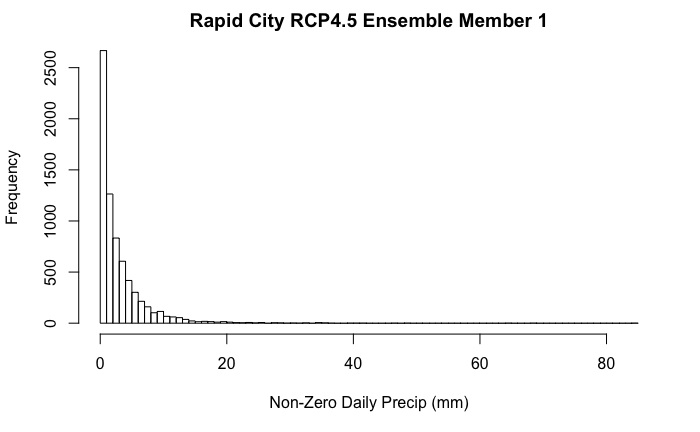

```r
ens_target = 1 # just use the first ensemble member
subset = subset(precip,
                (Ensemble==ens_target)  &
                ((year>=base_start) &
                 (year<=base_end)   )
                )
# always nice to see what your data looks like.
hist(x      = subset$RCP45[subset$RCP45>0], # omitting zero precip days
     xlab   = "Non-Zero Daily Precip (mm)",
     main   = paste(location_name,
                    "RCP4.5 Ensemble Member 1",
                    sep = " "),
     freq   = TRUE,
     breaks = 100
     )
```

Now we run the fit command.

We will need a minimum threshold or the method fails.

Chose a reasonable value, here we chose 2mm (0.08“)

For reference, a wetting rain event is 0.1" or 2.54 mm

We are also using the Generalized Pareto method.

```r
fit_GP  = fevd(x          = RCP45,
               data       = subset,
               units      = "mm",
               time.units = "days",
               threshold  = 2.0,
               type       = "GP",
               verbose    = TRUE,
               span       = period_span
               )
```

```
 Data span  0.08213552 years
Setting up parameter model design matrices.
Parameter model design matrices set up.
Using Lmoments estimates as initial estimates.  Initial value = 7262.359
Initial estimates are:
    scale     shape
3.0370336 0.2117868
Beginning estimation procedure.
Time difference of 0.6175518 secs
```

And we plot the results. You would prefer for the lines to rest on the “1:1” through a reasonable period. For a 30 year span, I’ll consider 15 return yers to be acceptable.

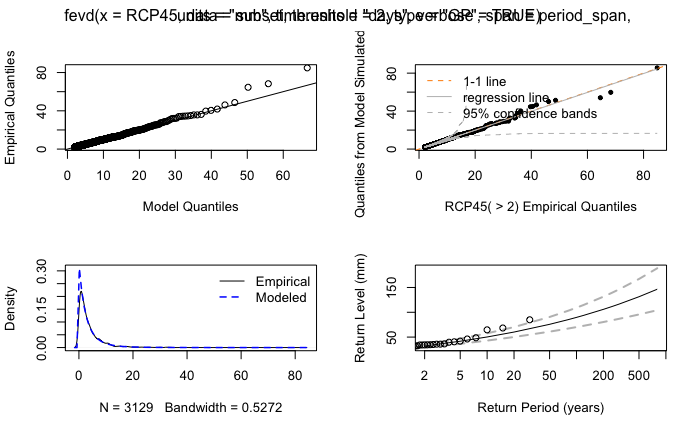

```r
plot(fit_GP)
```

```r
plot(fit_GP,"lr")
```

```
Error in match.arg(type) :
  'arg' should be one of “primary”, “probprob”, “qq”, “qq2”, “Zplot”, “hist”, “density”, “rl”, “trace”
```

We can also extract specific return events.

```r
return_intervals = seq(from =              2,
                       to   =  period_span/2,
                       by   =              1)
n_return_intervals = length(return_intervals)
return_GP = return.level(x             = fit_GP,
                         return.period = return_intervals,
                         do.ci         = TRUE)
print(return_GP)
```

```
fevd(x = RCP45, data = subset, threshold = 2, type = "GP", span = period_span,
    units = "mm", time.units = "days", verbose = TRUE)

[1] "Normal Approx."

                     95% lower CI Estimate 95% upper CI
2-year return level      28.90378 32.11618     35.32858
3-year return level      32.10457 36.11213     40.11970
4-year return level      34.50462 39.16378     43.82295
5-year return level      36.44331 41.66286     46.88241
6-year return level      38.07899 43.79468     49.51038
7-year return level      39.49913 45.66276     51.82640
8-year return level      40.75747 47.33123     53.90500
9-year return level      41.88951 48.84279     55.79608
10-year return level     42.92001 50.22740     57.53480
11-year return level     43.86694 51.50695     59.14697
12-year return level     44.74380 52.69797     60.65213
13-year return level     45.56099 53.81323     62.06547
14-year return level     46.32672 54.86288     63.39903
15-year return level     47.04756 55.85506     64.66256
```

```r
# tidy up the demo
remove(return_GP,
       fit_GP,
       subset)
```

```
Error in names(frame)[names(frame) == "x"] <- name :
  names() applied to a non-vector
```

To implement. Let’s create the storage arrays We will copy this over and over.

```r
# for each case/period create arrays for the return and CI bounds
# first for our base period
rcp45_base_period_return  = array(data= 0,
                                  dim = c(n_ensembles,
                                          n_return_intervals))
dimnames(rcp45_base_period_return) = list(ensemble,
                                         return_intervals)
rcp45_base_period_ci_ub   = rcp45_base_period_return
rcp45_base_period_ci_lb   = rcp45_base_period_return
rcp85_base_period_return  = rcp45_base_period_return
rcp85_base_period_ci_ub   = rcp45_base_period_return
rcp85_base_period_ci_lb   = rcp45_base_period_return
# then for our test period(s)
rcp45_per1_period_return  = rcp45_base_period_return
rcp45_per1_period_ci_ub   = rcp45_base_period_return
rcp45_per1_period_ci_lb   = rcp45_base_period_return
rcp85_per1_period_return  = rcp45_base_period_return
rcp85_per1_period_ci_ub   = rcp45_base_period_return
rcp85_per1_period_ci_lb   = rcp45_base_period_return
```

create a loop that goes between the ensembles.

```r
for (ens_target in 1:n_ensembles) {

  ######################################
  #
  # Base Period
  #

  # create segments for RCP 45 and RCP 85 for your period(s)

  subset = subset(precip,
                  (Ensemble==ens_target)  &
                  ((year>=base_start) &
                     (year<=base_end)   )
                       )

  # fit an extreme value dist to the data

  fit_GP_45 = fevd(x          = RCP45,
                   data       = subset,
                   units      = "mm",
                   time.units = "365/year",
                   threshold  = 2.0,
                   type       = "GP",
                   verbose    = FALSE,
                   span       = period_span
                   )

  fit_GP_85 = fevd(x          = RCP85,
                   data       = subset,
                   units      = "mm",
                   time.units = "365/year",
                   threshold  = 2.0,
                   type       = "GP",
                   verbose    = FALSE,
                   span       = period_span
                   )

  # calculate the return periods and load into the temporary storage arrays.

  return_GP = return.level(x             = fit_GP_45,
                           return.period = return_intervals,
                           do.ci         = TRUE)

  rcp45_base_period_ci_lb[ ens_target, ] = return_GP[ , 1]
  rcp45_base_period_return[ens_target, ] = return_GP[ , 2]
  rcp45_base_period_ci_ub[ ens_target, ] = return_GP[ , 3]

  return_GP = return.level(x             = fit_GP_85,
                           return.period = return_intervals,
                           do.ci         = TRUE)

  rcp85_base_period_ci_lb[ ens_target, ] = return_GP[ , 1]
  rcp85_base_period_return[ens_target, ] = return_GP[ , 2]
  rcp85_base_period_ci_ub[ ens_target, ] = return_GP[ , 3]

  # tidy up

  remove(subset,
         fit_GP_45,
         fit_GP_85,
         return_GP)
  #
  ######################################


  ######################################
  #
  #  Period #1
  #

  # create segments for RCP 45 and RCP 85 for your period(s)

  subset = subset(precip,
                  (Ensemble==ens_target)  &
                  ((year>=per1_start) &
                     (year<=per1_end)   )
                       )

  # fit an extreme value dist to the data

  fit_GP_45 = fevd(x          = RCP45,
                   data       = subset,
                   units      = "mm",
                   time.units = "365/year",
                   threshold  = 2.0,
                   type       = "GP",
                   verbose    = FALSE,
                   span       = period_span
                   )

  fit_GP_85 = fevd(x          = RCP85,
                   data       = subset,
                   units      = "mm",
                   time.units = "365/year",
                   threshold  = 2.0,
                   type       = "GP",
                   verbose    = FALSE,
                   span       = period_span
                   )

  # calculate the return periods and load into the temporary storage arrays.

  return_GP = return.level(x             = fit_GP_45,
                           return.period = return_intervals,
                           do.ci         = TRUE)

  rcp45_per1_period_ci_lb[ ens_target, ] = return_GP[ , 1]
  rcp45_per1_period_return[ens_target, ] = return_GP[ , 2]
  rcp45_per1_period_ci_ub[ ens_target, ] = return_GP[ , 3]

  return_GP = return.level(x             = fit_GP_85,
                           return.period = return_intervals,
                           do.ci         = TRUE)

  rcp85_per1_period_ci_lb[ ens_target, ] = return_GP[ , 1]
  rcp85_per1_period_return[ens_target, ] = return_GP[ , 2]
  rcp85_per1_period_ci_ub[ ens_target, ] = return_GP[ , 3]

  # tidy up

  remove(subset,
         fit_GP_45,
         fit_GP_85,
         return_GP)
  #
  ######################################

}
```

Convert output into neat and tidy data frames

```r
################################################
#
# let's start with the base period
#
# melt 2-d arrays into frames.
rcp45_base   = melt(data       = rcp45_base_period_return,
                    varnames   = c("Ensembles","return_intervals"),
                    na.rm      = TRUE,
                    value.name = "RCP45_Return_Period")
rcp45_cib_lb = melt(data       = rcp45_base_period_ci_lb,
                    varnames   = c("Ensembles","return_intervals"),
                    na.rm      = TRUE,
                    value.name = "RCP45_Lower_95_CI")
rcp45_cib_ub = melt(data       = rcp45_base_period_ci_ub,
                    varnames   = c("Ensembles","return_intervals"),
                    na.rm      = TRUE,
                    value.name = "RCP45_Upper_95_CI")
rcp85_base   = melt(data       = rcp85_base_period_return,
                    varnames   = c("Ensembles","return_intervals"),
                    na.rm      = TRUE,
                    value.name = "RCP85_Return_Period")
rcp85_cib_lb = melt(data       = rcp85_base_period_ci_lb,
                    varnames   = c("Ensembles","return_intervals"),
                    na.rm      = TRUE,
                    value.name = "RCP85_Lower_95_CI")
rcp85_cib_ub = melt(data       = rcp85_base_period_ci_ub,
                    varnames   = c("Ensembles","return_intervals"),
                    na.rm      = TRUE,
                    value.name = "RCP85_Upper_95_CI")
# combine the fields into a single data frame for each one.
rcp45_base$RCP45_Lower_95_CI = rcp45_cib_lb$RCP45_Lower_95_CI
rcp45_base$RCP45_Upper_95_CI = rcp45_cib_ub$RCP45_Upper_95_CI
rcp85_base$RCP85_Lower_95_CI = rcp85_cib_lb$RCP85_Lower_95_CI
rcp85_base$RCP85_Upper_95_CI = rcp85_cib_ub$RCP85_Upper_95_CI
# tidy up
remove(rcp85_base_period_ci_lb,
       rcp85_base_period_return,
       rcp85_base_period_ci_ub,
       rcp85_cib_lb,
       rcp85_cib_ub)
remove(rcp45_base_period_ci_lb,
       rcp45_base_period_return,
       rcp45_base_period_ci_ub,
       rcp45_cib_lb,
       rcp45_cib_ub)
#
################################################
################################################
#
# and we can continue with the test period
#
rcp45_per1   = melt(data       = rcp45_per1_period_return,
                    varnames   = c("Ensembles","return_intervals"),
                    na.rm      = TRUE,
                    value.name = "RCP45_Return_Period")
rcp45_ci1_lb = melt(data       = rcp45_per1_period_ci_lb,
                    varnames   = c("Ensembles","return_intervals"),
                    na.rm      = TRUE,
                    value.name = "RCP45_Lower_95_CI")
rcp45_ci1_ub = melt(data       = rcp45_per1_period_ci_ub,
                    varnames   = c("Ensembles","return_intervals"),
                    na.rm      = TRUE,
                    value.name = "RCP45_Upper_95_CI")
rcp85_per1   = melt(data       = rcp85_per1_period_return,
                    varnames   = c("Ensembles","return_intervals"),
                    na.rm      = TRUE,
                    value.name = "RCP85_Return_Period")
rcp85_ci1_lb = melt(data       = rcp85_per1_period_ci_lb,
                    varnames   = c("Ensembles","return_intervals"),
                    na.rm      = TRUE,
                    value.name = "RCP85_Lower_95_CI")
rcp85_ci1_ub = melt(data       = rcp85_per1_period_ci_ub,
                    varnames   = c("Ensembles","return_intervals"),
                    na.rm      = TRUE,
                    value.name = "RCP85_Upper_95_CI")
# combine the fields into a single data frame for each one.
rcp45_per1$RCP45_Lower_95_CI = rcp45_ci1_lb$RCP45_Lower_95_CI
rcp45_per1$RCP45_Upper_95_CI = rcp45_ci1_ub$RCP45_Upper_95_CI
rcp85_per1$RCP85_Lower_95_CI = rcp85_ci1_lb$RCP85_Lower_95_CI
rcp85_per1$RCP85_Upper_95_CI = rcp85_ci1_ub$RCP85_Upper_95_CI
# tidy up
remove(rcp85_per1_period_ci_lb,
       rcp85_per1_period_return,
       rcp85_per1_period_ci_ub,
       rcp85_ci1_lb,
       rcp85_ci1_ub)
remove(rcp45_per1_period_ci_lb,
       rcp45_per1_period_return,
       rcp45_per1_period_ci_ub,
       rcp45_ci1_lb,
       rcp45_ci1_ub)
#
################################################
```

Plot return output

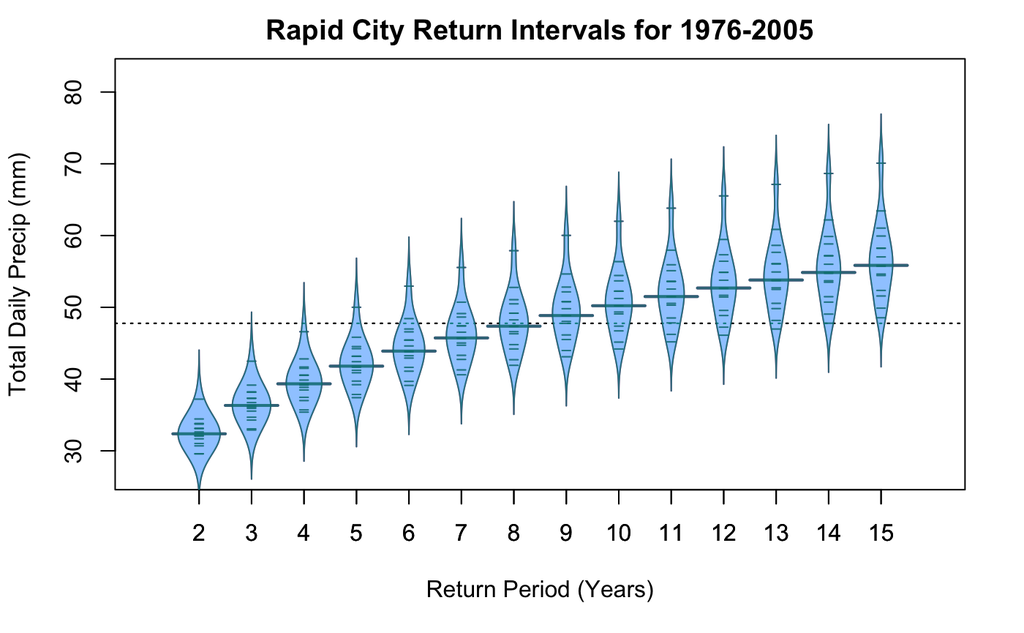

```r
# I am making my own colours
darkcyan = rgb(red   = 0.00,
               green = 0.50,
               blue  = 0.50,
               alpha = 0.75)  # 1 = opaque; 0 = fully clear
cyan     = rgb(red   = 0.00,
               green = 1.00,
               blue  = 1.00,
               alpha = 0.50)
darkblue = rgb(red   = 0.00,
               green = 0.00,
               blue  = 0.50,
               alpha = 0.75)
blue     = rgb(red   = 0.00,
               green = 0.00,
               blue  = 1.00,
               alpha = 0.50)
darkmag  = rgb(red   = 0.50,
               green = 0.00,
               blue  = 0.50,
               alpha = 0.75)
magenta  = rgb(red   = 1.00,
               green = 0.00,
               blue  = 1.00,
               alpha = 0.50)
darkred  = rgb(red   = 0.50,
               green = 0.00,
               blue  = 0.00,
               alpha = 0.75)
red      = rgb(red   = 1.00,
               green = 0.00,
               blue  = 0.00,
               alpha = 0.50)
beanplot(formula     = RCP85_Return_Period~return_intervals,  # formula selection for y axis
         data        = rcp85_base,                            # data frame to use
         col         = c(magenta,  # area fill                # Color Scheme
                         darkmag,  # lines
                         darkmag,  # outside of bean line
                         darkmag), # mean line
         border      = darkmag,                               # border color
         overallline = "median",                              # can't get rid of this dang thing
         beanlines   = "median",                              # use median for the "central value"
         main        = paste(location_name,
                             " Return Intervals for ",         # title caption
                             base_start,
                            "-",
                            base_end,
                            sep=""),
         xlab        = "Return Period (Years)",               # xaxis title
         ylab        = paste(variable_name,                   # yaxis title
                             " (",
                             variable_units,
                             ")",
                             sep=""),
         log         = "",                                    # overide log axis on y (it defaults to log for big datasets)
         xlim        = c(0, period_span/2),                   # x axis range
         ylim        = c(min(rcp45_base$RCP45_Lower_95_CI,    # y axis range
                             rcp85_base$RCP85_Lower_95_CI),
                         max(rcp45_base$RCP45_Upper_95_CI,
                             rcp85_base$RCP85Upper_95_CI)
                        )
        )


beanplot(formula    = RCP45_Return_Period~return_intervals,
         data        = rcp45_base,
         add         = TRUE,
         beanlines   = "median",
         overallline = "median",
         col         = c(cyan,      # area fill
                         darkcyan,  # lines
                         darkcyan,  # outside of bean line
                         darkcyan), # mean line
         border      = darkcyan
        )
```

Trying something new. Now we can do this a “split” plot.

This requires another melt.

```r
# create a temporary array to hold just the return periods for simplicity
deleteme     = data.frame(Ensembles        = rcp45_base$Ensembles,
                          return_intervals = rcp45_base$return_intervals,
                          RCP45            = rcp45_base$RCP45_Return_Period,
                          RCP85            = rcp85_base$RCP85_Return_Period)
# melt the RCP45 and RCP85 columns into a new field.
base_all     = melt(data       = deleteme,
                    varnames   = c("Ensembles","return_intervals","Scenario"),
                    id.vars    = c("Ensembles","return_intervals"),
                    na.rm      = TRUE,
                    value.name = "Return_Period_Values")
colnames(base_all) <- c("Ensembles","return_intervals","Scenario","Return_Period_Values")
# for this to work below, the program will need to search through ONE variable for the axis
# you can use two (or more) sub-categories.
#
# to do this you need to create a new variable in the data table that will have two
# parts, separated by a space character.
#
# this your x-axis + "series" category would be
#
#  001 Cat1
#  002 Cat1
#  003 Cat1
#  001 Cat2
#  002 Cat3
# ... and so on.
#
# in this case we will have our return period year and then the RCP scenario.
# (We could also do this for different periods for a single RCP scenario)
#
# thus...
#  02 RCP45 (we need that leading zero)
#  02 RCP85
#   ...
#  20 RCP45
#  20 RCP85
base_all$merged_period_scenarios = paste(sprintf("%02d", base_all$return_intervals),
                                         base_all$Scenario,
                                         sep = " ")
# tidy up!
remove(deleteme)
```

And now we can plot this one. This will create a “split” bean plot which is about as complex and messy as I want to get right now.

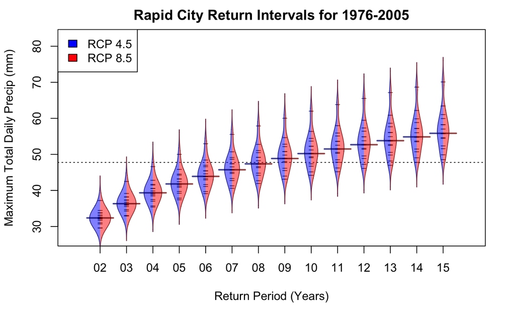

```r
beanplot(formula     = Return_Period_Values~merged_period_scenarios,  # formula selection for y axis
         data        = base_all,                                     # data frame to use
         col         = list(c(blue, darkblue,darkblue,darkblue),  # same order as earlier for each series
                            c(red,  darkred,  darkred, darkred)),
         border      = c(darkblue,darkred),
         overallline = "median",                              # can't get rid of this dang thing
         beanlines   = "median",                              # use median for the "central value"
         side        = "both",
         main        = paste(location_name,
                             " Return Intervals for ",         # title caption
                             base_start,
                             "-",
                             base_end,
                             sep=""),
         xlab        = "Return Period (Years)",               # xaxis title
         ylab        = paste("Maximum ",
                             variable_name,                   # yaxis title
                             " (",
                             variable_units,
                             ")",
                             sep=""),
         log         = "",                                    # overide log axis on y (it defaults to log for big datasets)
         xlim        = c(0, period_span/2),                   # x axis range
         ylim        = c(min(rcp45_base$RCP45_Lower_95_CI,    # y axis range
                             rcp85_base$RCP85_Lower_95_CI),
                         max(rcp45_base$RCP45_Upper_95_CI,
                             rcp85_base$RCP85Upper_95_CI)
                        )
        )
legend("topleft",
       fill   = c("blue", "red"),
       legend = c("RCP 4.5", "RCP 8.5"))
```

Now let’s try this again and do a comparison between the RCP 8.5 between the base period and the future period.

So we will merge-n-melt the RCP85 Base and Period 1 values into a single data set.

```r
##################################################
#
#  Processing RCP 8.5
#
# create a temporary array to hold just the return periods for simplicity
deleteme     = data.frame(Ensembles        = rcp85_base$Ensembles,
                          return_intervals = rcp85_base$return_intervals,
                          Baseline         = rcp85_base$RCP85_Return_Period,
                          TestPeriod       = rcp85_per1$RCP85_Return_Period)
colnames(deleteme) = c("Ensembles","return_intervals",
                        paste(base_start, "-", base_end, sep=""),
                        paste(per1_start, "-", per1_end, sep=""))
# melt the two period columns into a new field.
rcp85_all    = melt(data       = deleteme,
                    varnames   = c("Ensembles","return_intervals","Time_Period"),
                    id.vars    = c("Ensembles","return_intervals"),
                    na.rm      = TRUE,
                    value.name = "Return_Period_Values")
colnames(rcp85_all) = c("Ensembles","return_intervals","Time_Period","Return_Period_Values")
# create the merged variable for plotting...
rcp85_all$merged_period_scenarios = paste(sprintf("%02d", rcp85_all$return_intervals),
                                          rcp85_all$Time_Period,
                                          sep = " ")
# tidy up
remove (deleteme)
#
##################################################
```

And let’s plot ’er up!

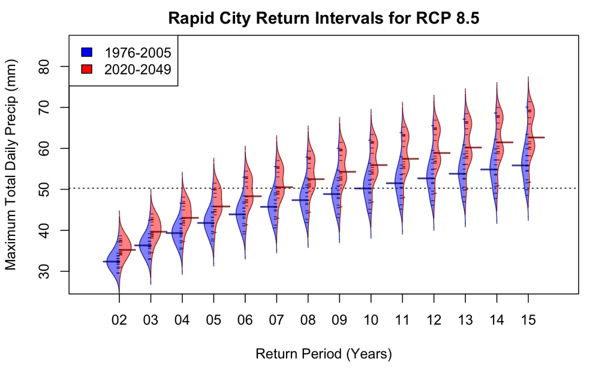

```r
beanplot(formula     = Return_Period_Values~merged_period_scenarios,  # formula selection for y axis
         data        = rcp85_all,                                     # data frame to use
         col         = list(c(blue, darkblue,darkblue,darkblue),  # same order as earlier for each series
                            c(red,  darkred,  darkred, darkred)),
         border      = c(darkblue,darkred),
         overallline = "median",                              # can't get rid of this dang thing
         beanlines   = "median",                              # use median for the "central value"
         side        = "both",
         main        = paste(location_name,
                             "Return Intervals for RCP 8.5",
                             sep = " "),         # title caption
         xlab        = "Return Period (Years)",               # xaxis title
         ylab        = paste("Maximum ",
                             variable_name,                   # yaxis title
                             " (",
                             variable_units,
                             ")",
                             sep=""),
         log         = "",                                    # overide log axis on y (it defaults to log for big datasets)
         xlim        = c(0, period_span/2),                   # x axis range
         ylim        = c(min(rcp45_base$RCP45_Lower_95_CI,    # y axis range
                             rcp45_per1$RCP45_Lower_95_CI,
                             rcp85_base$RCP45_Lower_95_CI,
                             rcp85_per1$RCP45_Lower_95_CI),
                         max(rcp45_base$RCP45_Upper_95_CI,
                             rcp45_per1$RCP45_Upper_95_CI,
                             rcp45_base$RCP45_Upper_95_CI,
                             rcp85_per1$RCP45_Upper_95_CI)
                        )
        )
legend("topleft",
       fill = c("blue", "red"),
       legend = c(paste(base_start, "-", base_end, sep=""),
                  paste(per1_start, "-", per1_end, sep=""))
       )
```

And a few CAREFUL cuts and pastes will do the same for the 4.5!

```r
##################################################
#
#  Processing RCP 4.5
#
# create a temporary array to hold just the return periods for simplicity
deleteme     = data.frame(Ensembles        = rcp45_base$Ensembles,
                          return_intervals = rcp45_base$return_intervals,
                          Baseline         = rcp45_base$RCP45_Return_Period,
                          TestPeriod       = rcp45_per1$RCP45_Return_Period)
colnames(deleteme) = c("Ensembles","return_intervals",
                        paste(base_start, "-", base_end, sep=""),
                        paste(per1_start, "-", per1_end, sep=""))
# melt the two period columns into a new field.
rcp45_all    = melt(data       = deleteme,
                    varnames   = c("Ensembles","return_intervals","Time_Period"),
                    id.vars    = c("Ensembles","return_intervals"),
                    na.rm      = TRUE,
                    value.name = "Return_Period_Values")
colnames(rcp45_all) = c("Ensembles","return_intervals","Time_Period","Return_Period_Values")
# create the merged variable for plotting...
rcp45_all$merged_period_scenarios = paste(sprintf("%02d", rcp45_all$return_intervals),
                                          rcp85_all$Time_Period,
                                          sep = " ")
# tidy up
remove (deleteme)
#
##################################################
```

And let’s plot ’er up!

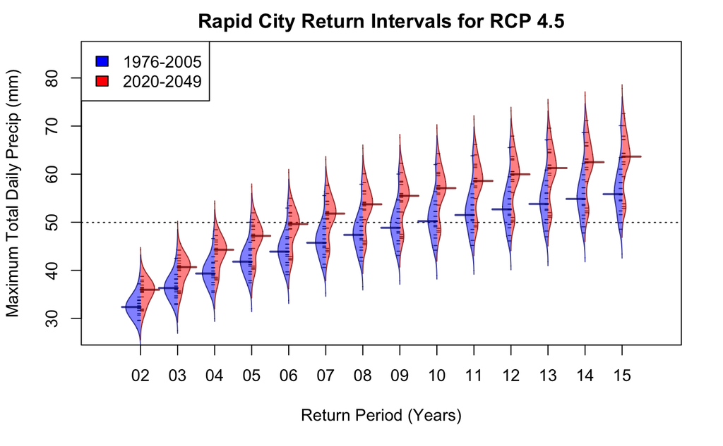

```r
beanplot(formula     = Return_Period_Values~merged_period_scenarios,  # formula selection for y axis
         data        = rcp45_all,                                     # data frame to use
         col         = list(c(blue, darkblue,darkblue,darkblue),  # same order as earlier for each series
                            c(red,  darkred,  darkred, darkred)),
         border      = c(darkblue,darkred),
         overallline = "median",                              # can't get rid of this dang thing
         beanlines   = "median",                              # use median for the "central value"
         side        = "both",
         main        = paste(location_name,
                             "Return Intervals for RCP 4.5",
                             sep = " "),         # title caption
         xlab        = "Return Period (Years)",               # xaxis title
         ylab        = paste("Maximum ",
                             variable_name,                   # yaxis title
                             " (",
                             variable_units,
                             ")",
                             sep=""),
         log         = "",                                    # overide log axis on y (it defaults to log for big datasets)
         xlim        = c(0, period_span/2),                   # x axis range
         ylim        = c(min(rcp45_base$RCP45_Lower_95_CI,    # y axis range
                             rcp45_per1$RCP45_Lower_95_CI,
                             rcp85_base$RCP45_Lower_95_CI,
                             rcp85_per1$RCP45_Lower_95_CI),
                         max(rcp45_base$RCP45_Upper_95_CI,
                             rcp45_per1$RCP45_Upper_95_CI,
                             rcp45_base$RCP45_Upper_95_CI,
                             rcp85_per1$RCP45_Upper_95_CI)
                        )
        )
legend("topleft",
       fill = c("blue", "red"),
       legend = c(paste(base_start, "-", base_end, sep=""),
                  paste(per1_start, "-", per1_end, sep=""))
       )
```